# Project: Identify Customer Segments

### Discussion 2.2: Perform Dimensionality Reduction

- From our scree plot and bar plot above, we observe that **PC1** accounts for 16% of variation, while **PC2** 11%
- There are several rules of thumbs to determine number of Principal components, e.g. selecting PCs which account > 5%, or pre-determining the error % we want and derive the number of PCs from there
- Considering our number of features and observations, having a high PC will be computationally intensive in our modelling
- I have determined that a 10% error, or 90% of variation explained will be more than sufficient for our modelling, based on inputs from individuals from [source](https://www.researchgate.net/post/What-should-the-minumum-explained-variance-be-to-be-acceptable-in-factor-analysis), who have suggested percentages of 50% - 70% depending on subject matter
- 90% is well above these suggestions, n_components of 37 is chosen as it would hap to 90% of variation explained per scree plot

### Step 2.3: Interpret Principal Components

Now that we have our transformed principal components, it's a nice idea to check out the weight of each variable on the first few components to see if they can be interpreted in some fashion.

As a reminder, each principal component is a unit vector that points in the direction of highest variance (after accounting for the variance captured by earlier principal components). The further a weight is from zero, the more the principal component is in the direction of the corresponding feature. If two features have large weights of the same sign (both positive or both negative), then increases in one tend expect to be associated with increases in the other. To contrast, features with different signs can be expected to show a negative correlation: increases in one variable should result in a decrease in the other.

- To investigate the features, you should map each weight to their corresponding feature name, then sort the features according to weight. The most interesting features for each principal component, then, will be those at the beginning and end of the sorted list. Use the data dictionary document to help you understand these most prominent features, their relationships, and what a positive or negative value on the principal component might indicate.
- You should investigate and interpret feature associations from the first three principal components in this substep. To help facilitate this, you should write a function that you can call at any time to print the sorted list of feature weights, for the *i*-th principal component. This might come in handy in the next step of the project, when you interpret the tendencies of the discovered clusters.

```python
# To obtain translation column for attributes
columns = scaled_azdias.columns

# https://stackoverflow.com/questions/33027643/return-single-cell-value-from-pandas-dataframe/33027904
before_last_15 = pd.Series(columns[:-15]).apply(lambda x : feat_info.loc[feat_info['attribute'] == x, 'attribute_trans'].values[0])
columns_trans = before_last_15.append(pd.Series(columns[-15:]))
columns_trans.head()
```

```
0    Estimated age based on given name analysis
1                                        Gender
2                        low financial interest
3              Financial typology - money-saver
4              Financial typology - be prepared
dtype: object
```

```python
def pc_variance(pca, pc_num, num_limit=10):
    pc = pd.DataFrame({'attribute':columns, 'attribute_trans':columns_trans, 'score' : all_pca.components_[pc_num - 1]})
    pc_sorted = pc.sort_values(by='score', ascending=True)
    pc_filtered = pc_sorted.iloc[0:num_limit].append(pc_sorted.iloc[-num_limit:])
    pc_filtered.reset_index(inplace=True, drop=True)

    plt.figure(figsize=(10, 8))
    plt.yticks(pc_filtered.index, pc_filtered['attribute_trans'] + " - " + pc_filtered['attribute'])
    plt.barh(pc_filtered.index, pc_filtered['score'])
    plt.title(f'Top and under {num_limit} variance explained for Principal Component {pc_num}')
    plt.ylabel('Feature')
    plt.xlabel('Variance explained')
    plt.show()
```

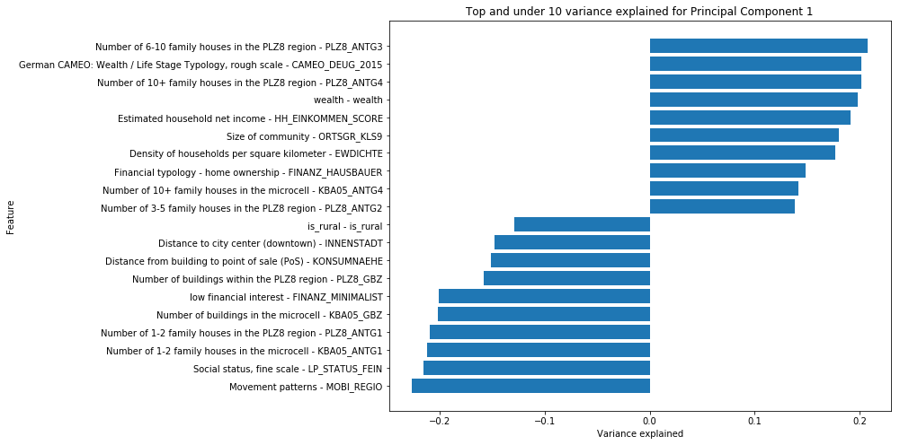

```python
# Map weights for the first principal component to corresponding feature names
# and then print the linked values, sorted by weight.
pc_variance(all_pca, 1)
```

### PC1 - Measure of Poorness

#### Positive correlations

1. **High density living** - tend to have higher number of houses in the region (PLZ8_ANTG3, PLZ8_ANTG4), hence higher density of households (EWDICHTE)
2. **Lack of Money** - higher 'wealth' score and household net income score (HH_EINKOMMEN_SCORE)
   - **Note: the higher the score, the lower the wealth and net income**

#### Negative correlations

1. **Movement** - lower score (which is higher movement)
   - poorer households tend to move more frequently than other households, as they are more likely to experience negative mobility in the form of evictions and homeless episodes. [Link](https://www.jstor.org/stable/10.1086/673963#:~:text=Although%20mobility%20is%20common%20across,%3B%20Nichols%20and%20Gault%202003).)
2. **Lower social status** (LP_STATUS_FEIN)

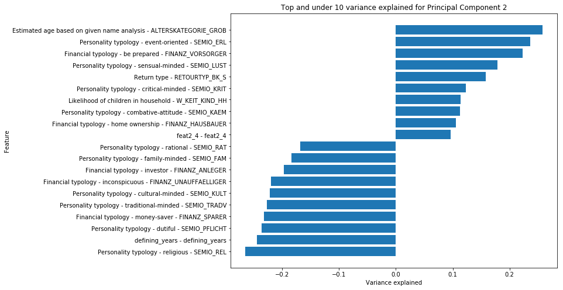

```python
# Map weights for the second principal component to corresponding feature names
# and then print the linked values, sorted by weight.
pc_variance(all_pca, 2)
```

### PC2 - Measure of Older Generation

#### Positive correlations

1. **Estimated age given name analysis** (ALTERSKATEGORIE_GROB) - older people with names of previous generations tend to be clumped together
2. **Less active or event oriented** - Higher score equates to being less event oriented. Older people tend to be less active
3. **Less lustful** (SEMIO_LUST) - Higher score equates to being less lustful. Older people tend to be less lust-ful than the younger generation

#### Negative correlations

1. **Less secular (more religious)** - lower score of SEMIO_REL equates to being more religious
2. **Defining years** - Older people tend to equate defining years to a much earlier period
3. **Less liberal (more conservative)** - Elderly tend to have more conservative personalities, e.g. being dutiful (SEMIO_PFLICHT), traditional (SEMIO_TRADV) and appreciative of culture more (SEMIO_KULT). And financial more of a money saver (FINANZ_SPARER)

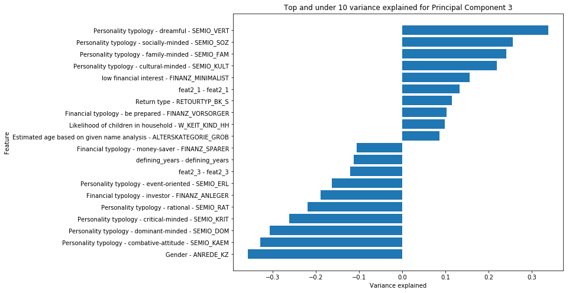

```python
# Map weights for the third principal component to corresponding feature names
# and then print the linked values, sorted by weight.
pc_variance(all_pca, 3)
```

### PC3 - Measure of Masculinity and emphasis over rationality

- **Note**, a lower score in these typology surveys **would mean the inverse**

#### Positive and negative correlations

1. **Personalities** - higher masculinity would mean having more of a combative attitude (SEMIO_KAEM), more dominant (SEMIO_DOM), a more rational person would be more critically-minded (SEMIO_KRIT) and rational (SEMIO_RAT)
   - the inverse can be observed for qualities for being dreamful (SEMIO_VERT), socially-minded (SEMIO_SOZ)
2. **Gender** - These qualities are more often associated with males, hence gender being geared negatively in the graph (since our data plots 1 as male and 2 as female)
3. **Activities** - Being more rational in day to day may equate to being more financially educated, hence a higher weight to being an investor (FINANZ_ANLEGER)
   - the inverse can be seen over low financial intesrest - FINANZ_MINIMALIST

### Discussion 2.3: Interpret Principal Components

- Based on our analysis above, it can be concluded that:
  1. PC1 is a measure of **Poorness**, with emphasis over money, living density, social status, and movement pattenrs
  2. PC2 is a measure of **Elderly**, with emphasis over age (given prevalence of name), defining years during youth, and personalities relating to being more liberal/convervative
  3. PC3 is a measure of **Masculinity and Rationality**, with emphasis over more masculine and rational personalities, and indirectly, financial habits. Unsurprisingly, this PC has a higher weightage to males than females.

## Step 3: Clustering

### Step 3.1: Apply Clustering to General Population

You've assessed and cleaned the demographics data, then scaled and transformed them. Now, it's time to see how the data clusters in the principal components space. In this substep, you will apply k-means clustering to the dataset and use the average within-cluster distances from each point to their assigned cluster's centroid to decide on a number of clusters to keep.

- Use sklearn's KMeans class to perform k-means clustering on the PCA-transformed data.
- Then, compute the average difference from each point to its assigned cluster's center. **Hint**: The KMeans object's `.score()` method might be useful here, but note that in sklearn, scores tend to be defined so that larger is better. Try applying it to a small, toy dataset, or use an internet search to help your understanding.
- Perform the above two steps for a number of different cluster counts. You can then see how the average distance decreases with an increasing number of clusters. However, each additional cluster provides a smaller net benefit. Use this fact to select a final number of clusters in which to group the data. **Warning**: because of the large size of the dataset, it can take a long time for the algorithm to resolve. The more clusters to fit, the longer the algorithm will take. You should test for cluster counts through at least 10 clusters to get the full picture, but you shouldn't need to test for a number of clusters above about 30.
- Once you've selected a final number of clusters to use, re-fit a KMeans instance to perform the clustering operation. Make sure that you also obtain the cluster assignments for the general demographics data, since you'll be using them in the final Step 3.3.

```python
from sklearn.cluster import KMeans
import time
# Over a number of different cluster counts...
n_clusters = 30
# start form at least 2 clusters
cluster_lst = list(range(2, n_clusters + 1, 2))
cluster_score = []
```

```python
# run k-means clustering on the data and...
for i in cluster_lst:
    start_time = time.time()

    k_means = KMeans(i)
    k_means.fit(X_pca)
    score = k_means.score(X_pca)
    cluster_score.append(score)
    print(f"--- Run time for n_clusters {i}: {np.round(((time.time() - start_time)/60),2)} mins ---, score is {score}")
    # compute the average within-cluster distances.
```

```
--- Run time for n_clusters 2: 0.24 mins ---, score is -37425960.527740836
--- Run time for n_clusters 4: 0.47 mins ---, score is -32857360.77450939
--- Run time for n_clusters 6: 0.79 mins ---, score is -30550748.883114334
--- Run time for n_clusters 8: 1.26 mins ---, score is -28899705.24693237
--- Run time for n_clusters 10: 2.13 mins ---, score is -27864301.37644421
--- Run time for n_clusters 12: 2.19 mins ---, score is -26796168.229933113
--- Run time for n_clusters 14: 3.3 mins ---, score is -26214934.694127638
--- Run time for n_clusters 16: 2.73 mins ---, score is -25691921.261498462
--- Run time for n_clusters 18: 4.31 mins ---, score is -25201990.141297184
--- Run time for n_clusters 20: 5.34 mins ---, score is -24549025.1052097
--- Run time for n_clusters 22: 4.66 mins ---, score is -24435932.30100823
--- Run time for n_clusters 24: 4.8 mins ---, score is -23739966.520439398
--- Run time for n_clusters 26: 5.82 mins ---, score is -23388650.194197442
```

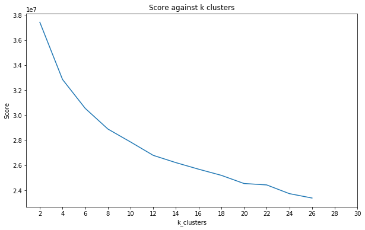

```python
# Investigate the change in within-cluster distance across number of clusters.

pos_cluster_score = [-x for x in cluster_score]
plt.figure(figsize=(10, 6))
plt.title('Score against k clusters')
plt.xlabel('k_clusters')
plt.ylabel('Score')
plt.plot(cluster_lst[:-2], pos_cluster_score)
plt.xticks(cluster_lst)
plt.show()
```

```python
# Re-fit the k-means model with the selected number of clusters and obtain
# cluster predictions for the general population demographics data.
final_k_means = KMeans(12)
```

### Discussion 3.1: Apply Clustering to General Population

- We utilise the elbow method to determine the optimum number of K clusters.
- However, it is not easily evident that there is an elbow in the graph, but there are several miniscule ones, i.e. 4, 8 and 12. The graph then tapers and slows down subsequent to 12 clusters.
- Considering that populations are generally wide, a good choice of clusters would be from 8 to 12, **12** will be chosen in efforts to test the model's precision more.

### Step 3.2: Apply All Steps to the Customer Data

Now that you have clusters and cluster centers for the general population, it's time to see how the customer data maps on to those clusters. Take care to not confuse this for re-fitting all of the models to the customer data. Instead, you're going to use the fits from the general population to clean, transform, and cluster the customer data. In the last step of the project, you will interpret how the general population fits apply to the customer data.

- Don't forget when loading in the customers data, that it is semicolon (`;`) delimited.
- Apply the same feature wrangling, selection, and engineering steps to the customer demographics using the `clean_data()` function you created earlier. (You can assume that the customer demographics data has similar meaning behind missing data patterns as the general demographics data.)
- Use the sklearn objects from the general demographics data, and apply their transformations to the customers data. That is, you should not be using a `.fit()` or `.fit_transform()` method to re-fit the old objects, nor should you be creating new sklearn objects! Carry the data through the feature scaling, PCA, and clustering steps, obtaining cluster assignments for all of the data in the customer demographics data.

```python
# Load in the customer demographics data.
customers = pd.read_csv('Udacity_CUSTOMERS_Subset.csv', sep=';')
```

```python
customers.describe()
```

|  | AGER_TYP | ALTERSKATEGORIE_GROB | ANREDE_KZ | CJT_GESAMTTYP | FINANZ_MINIMALIST | FINANZ_SPARER | FINANZ_VORSORGER | FINANZ_ANLEGER | FINANZ_UNAUFFAELLIGER | FINANZ_HAUSBAUER | ... | PLZ8_ANTG1 | PLZ8_ANTG2 | PLZ8_ANTG3 | PLZ8_ANTG4 | PLZ8_BAUMAX | PLZ8_HHZ | PLZ8_GBZ | ARBEIT | ORTSGR_KLS9 | RELAT_AB |
| --- | --- | --- | --- | --- | --- | --- | --- | --- | --- | --- | --- | --- | --- | --- | --- | --- | --- | --- | --- | --- | --- |
| count | 191652.000000 | 191652.000000 | 191652.000000 | 188439.000000 | 191652.000000 | 191652.000000 | 191652.000000 | 191652.000000 | 191652.000000 | 191652.000000 | ... | 138888.000000 | 138888.000000 | 138888.000000 | 138888.000000 | 138888.000000 | 138888.000000 | 138888.000000 | 141176.000000 | 141176.000000 | 141176.000000 |
| mean | 0.344359 | 3.060907 | 1.376432 | 3.677928 | 3.963773 | 2.057051 | 4.183317 | 2.439808 | 2.646176 | 2.781176 | ... | 2.537404 | 2.731510 | 1.388817 | 0.539939 | 1.556607 | 3.634893 | 3.622192 | 2.824850 | 5.119517 | 2.898510 |
| std | 1.391672 | 1.086254 | 0.484492 | 1.813975 | 1.036230 | 1.319422 | 0.995365 | 1.697932 | 1.586506 | 1.147353 | ... | 0.904927 | 0.840922 | 0.885038 | 0.637048 | 1.185736 | 0.933660 | 1.008472 | 1.012415 | 2.159184 | 1.422683 |
| min | -1.000000 | 1.000000 | 1.000000 | 1.000000 | 1.000000 | 1.000000 | 1.000000 | 1.000000 | 1.000000 | 1.000000 | ... | 0.000000 | 0.000000 | 0.000000 | 0.000000 | 1.000000 | 1.000000 | 1.000000 | 1.000000 | 1.000000 | 1.000000 |
| 25% | -1.000000 | 3.000000 | 1.000000 | 2.000000 | 3.000000 | 1.000000 | 3.000000 | 1.000000 | 1.000000 | 2.000000 | ... | 2.000000 | 2.000000 | 1.000000 | 0.000000 | 1.000000 | 3.000000 | 3.000000 | 2.000000 | 4.000000 | 2.000000 |
| 50% | 0.000000 | 3.000000 | 1.000000 | 4.000000 | 4.000000 | 1.000000 | 5.000000 | 2.000000 | 2.000000 | 3.000000 | ... | 3.000000 | 3.000000 | 1.000000 | 0.000000 | 1.000000 | 3.000000 | 4.000000 | 3.000000 | 5.000000 | 3.000000 |
| 75% | 2.000000 | 4.000000 | 2.000000 | 6.000000 | 5.000000 | 4.000000 | 5.000000 | 5.000000 | 5.000000 | 3.000000 | ... | 3.000000 | 3.000000 | 2.000000 | 1.000000 | 1.000000 | 4.000000 | 4.000000 | 4.000000 | 7.000000 | 4.000000 |
| max | 3.000000 | 9.000000 | 2.000000 | 6.000000 | 5.000000 | 5.000000 | 5.000000 | 5.000000 | 5.000000 | 5.000000 | ... | 4.000000 | 4.000000 | 3.000000 | 2.000000 | 5.000000 | 5.000000 | 5.000000 | 9.000000 | 9.000000 | 9.000000 |

8 rows × 81 columns

```python
# Apply preprocessing, feature transformation, and clustering from the general
# demographics onto the customer data, obtaining cluster predictions for the
# customer demographics data.
customers_clean = clean_data(customers)
customers_scaled = pd.DataFrame(standard_scaler.transform(customers_clean))
customers_pca = pd.DataFrame(pca.transform(customers_scaled))
```

### Step 3.3: Compare Customer Data to Demographics Data

At this point, you have clustered data based on demographics of the general population of Germany, and seen how the customer data for a mail-order sales company maps onto those demographic clusters. In this final substep, you will compare the two cluster distributions to see where the strongest customer base for the company is.

Consider the proportion of persons in each cluster for the general population, and the proportions for the customers. If we think the company's customer base to be universal, then the cluster assignment proportions should be fairly similar between the two. If there are only particular segments of the population that are interested in the company's products, then we should see a mismatch from one to the other. If there is a higher proportion of persons in a cluster for the customer data compared to the general population (e.g. 5% of persons are assigned to a cluster for the general population, but 15% of the customer data is closest to that cluster's centroid) then that suggests the people in that cluster to be a target audience for the company. On the other hand, the proportion of the data in a cluster being larger in the general population than the customer data (e.g. only 2% of customers closest to a population centroid that captures 6% of the data) suggests that group of persons to be outside of the target demographics.

Take a look at the following points in this step:

- Compute the proportion of data points in each cluster for the general population and the customer data. Visualizations will be useful here: both for the individual dataset proportions, but also to visualize the ratios in cluster representation between groups. Seaborn's [`countplot()`](https://seaborn.pydata.org/generated/seaborn.countplot.html) or [`barplot()`](https://seaborn.pydata.org/generated/seaborn.barplot.html) function could be handy.
  - Recall the analysis you performed in step 1.1.3 of the project, where you separated out certain data points from the dataset if they had more than a specified threshold of missing values. If you found that this group was qualitatively different from the main bulk of the data, you should treat this as an additional data cluster in this analysis. Make sure that you account for the number of data points in this subset, for both the general population and customer datasets, when making your computations!
- Which cluster or clusters are overrepresented in the customer dataset compared to the general population? Select at least one such cluster and infer what kind of people might be represented by that cluster. Use the principal component interpretations from step 2.3 or look at additional components to help you make this inference. Alternatively, you can use the `.inverse_transform()` method of the PCA and StandardScaler objects to transform centroids back to the original data space and interpret the retrieved values directly.
- Perform a similar investigation for the underrepresented clusters. Which cluster or clusters are underrepresented in the customer dataset compared to the general population, and what kinds of people are typified by these clusters?

```python
pred_azdias = final_k_means.fit_predict(X_pca)
pred_azdias_dist = pd.Series(pred_azdias).value_counts() / len(pred_azdias)
```

```python
pred_customers = final_k_means.predict(customers_pca)
pred_customers_dist = pd.Series(pred_customers).value_counts() / len(pred_customers)
```

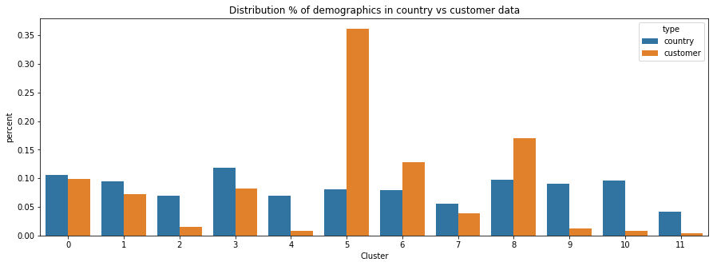

```python
# Compare the proportion of data in each cluster for the customer data to the
# proportion of data in each cluster for the general population.

comb = pd.DataFrame(pred_azdias_dist.append(pred_customers_dist))
comb['type'] = [('country' if x < 12 else 'customer') for x in range(24)]
comb.columns = ['percent', 'type']
plt.figure(figsize=(15, 5))
plt.title('Distribution % of demographics in country vs customer data')
plt.xlabel('Cluster')
plt.ylabel('Percentage')
ax = sns.barplot(data=comb, x=comb.index, hue='type', y='percent')
plt.show()
```

### Over-representation in customer data

- Cluster with index 5 accounts for the most in the customer data at around `35%`
  - It can be seen to be very negatively correlated to **PC1** and positively correlated to **PC3** and **PC4**
  - Following our analysis earlier PC1 represents poorness and PC3 masculinity/rationality, hence it can be concluded that this customer segment is predominantly wealthier than the general population and consists of more males (or people which have more masculine traits)
- We can observe similar patterns for **PC1** and **PC3** for cluster index 8, which is also represented in the general population
- An interesting finding is that clusters index 5 and 8 has inverse correlations for **PC4**, with cluster index 5 being positive and 8 negatively correlated. Upon further inspection, PC4 explains degree of **Unorthodox/[Avantgarde](https://en.wikipedia.org/wiki/Avant-garde) (or not being mainstream)**, with PC4 being positively correlated to being involved in `GREEN_AVANTGARDE` and having a `0` tagging for `mainstream_avantgarde`. The customer demographic seems to cater to both opinions.
- The final cluster with overrepresentation is cluster index 6, we observe that this cluster is predominantly elderly females.

```python
def cluster_feature_importances(cluster_index, cluster_centroid):
    plt.figure(figsize=(20, 6))
    label_lst = list(range(1, len(cluster_centroid[cluster_index]) + 1))
    plt.xticks(label_lst)
    plt.title(f'Weightage of cluster index {cluster_index}')
    plt.ylabel('Weightage')
    plt.xlabel('Principal component')
    plt.bar(label_lst, cluster_centroid[cluster_index])
    plt.show()
```

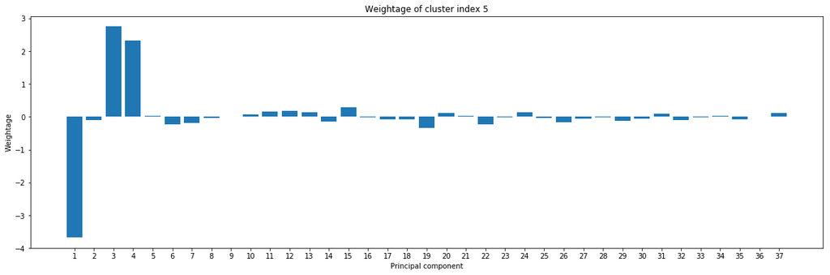

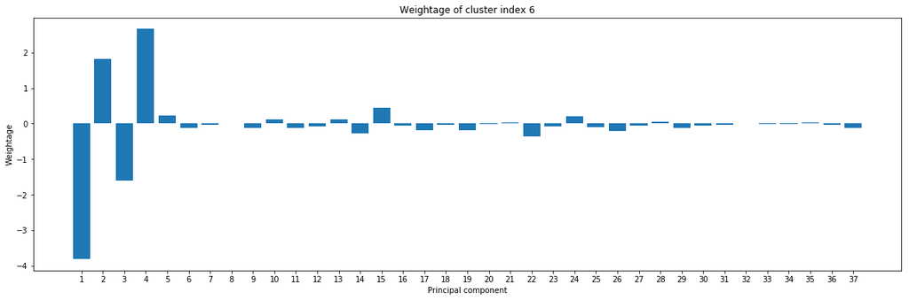

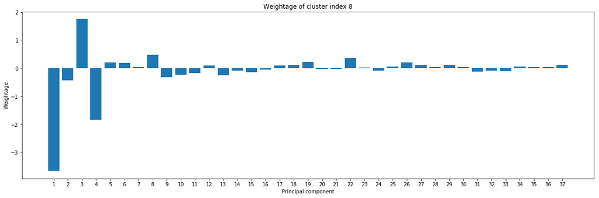

```python
# What kinds of people are part of a cluster that is overrepresented in the
# customer data compared to the general population?
cluster_feature_importances(5, final_k_means.cluster_centers_)
cluster_feature_importances(6, final_k_means.cluster_centers_)
cluster_feature_importances(8, final_k_means.cluster_centers_)
```

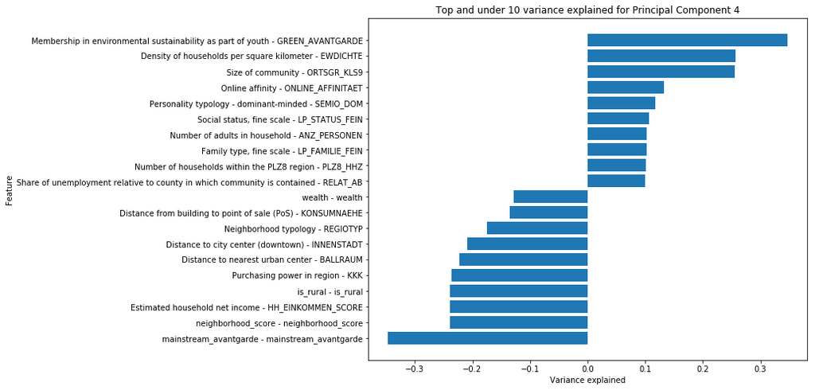

```python
pc_variance(all_pca, 4)
# 1 = Mainstream, 0 = Avantgarde
```